# MATH1324 Assignment 1

Modeling Body Measurements

## Student Details

Thomas Le (s3491287)

## Problem Statement

The ‘che.de’ was the chosen variable, which is the respondent’s chest depth in centimeters, measured at nipple level, mid-expiration for both male and females. The empirical data for chest depth will be used to provide parameters of a normal distribution function; mean and standard deviation. The empirical data will be fitted against a normal distribution function of the data to see whether the data for males and females best fits a normal distribution.

## Load Packages

```r
library(tidyr)
library(dplyr)
library(readxl)
library(MASS)
```

## Data

```r
bdims <- read_excel("bdims.xlsx")
class(bdims$che.de)
```

```
[1] "numeric"
```

```r
class(bdims$sex)
```

```
[1] "numeric"
```

```r
bdims$sex <- bdims$sex %>% factor(
  levels = c('0', '1'),
  labels = c("female", "male"))
class(bdims$sex)
```

```
[1] "factor"
```

```r
levels(bdims$sex)
```

```
[1] "female" "male"
```

```r
bdims2 <- bdims[c(4,25)]
males <- bdims %>% filter(sex == "male")
females <- bdims %>% filter(sex == "female")
males_chest <- males[c(4,25)]
females_chest <- females[c(4,25)]
```

Imported data using readxl package. Assigned the variable ‘sex’ as a factor and labeled relevant names. The data was then filtered into males and females. Then again selected for chest depth for both males and females separately.

## Summary Statistics

```r
bdims2 %>% group_by(sex) %>% summarise(Min = min(che.de, na.rm = TRUE),
                                              median = median(che.de,probs = .25, na.rm = TRUE),
                                       Q1 = quantile(che.de, probs = .25, na.rm = TRUE),
                                              Q3 = quantile(che.de,probs = .75, na.rm = TRUE),
                                       IQR = IQR(che.de, na.rm = TRUE),

                                              Max = max(che.de, na.rm = TRUE),
                                              Mean = mean(che.de, na.rm = TRUE),
                                              SD = sd(che.de, na.rm = TRUE),
                                              n = n(),
                                              Missing = sum(is.na(che.de)))
```

| sex | Min | median | Q1 | Q3 | IQR | Max | Mean | SD | n | Missing |
| --- | --- | --- | --- | --- | --- | --- | --- | --- | --- | --- |
| female | 14.3 | 17.5 | 16.50 | 18.7 | 2.20 | 26.8 | 17.72462 | 1.832064 | 260 | 0 |
| male | 14.4 | 20.6 | 19.35 | 22.1 | 2.75 | 27.5 | 20.80648 | 2.143633 | 247 | 0 |

## Distribution Fitting

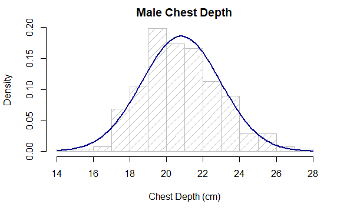

```r
malegraph <- hist(males_chest$che.de, breaks = 10, density = 10,
                  col = "gray", xlab = "Chest Depth (cm)", main = "Male Chest Depth", probability = TRUE)
curve(dnorm(x, mean = 20.806, sd = 2.144), col = "darkblue", lwd=2, add = TRUE, yaxt="n")
```

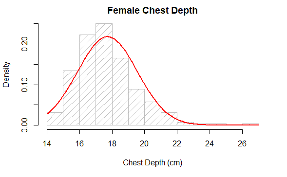

```r
femalegraph <- hist(females_chest$che.de, breaks = 10, density = 10,
                  col = "gray", xlab = "Chest Depth (cm)", main = "Female Chest Depth", probability = TRUE)
curve(dnorm(x, mean = 17.725, sd = 1.832), col = "red", lwd=2, add = TRUE, yaxt="n")
```

- Histogram frequency was plotted for chest depth in both males and females separately. The empirical data probabilty was shown by using the ‘probability = TRUE commmand’, to show the probability of each chest depth. The normal distribution was added/fitted over the histogram, using the parameters found in the summary statistics; the mean and standard deviation (which is used for a normal distribution function ~ N(μ,σ)). The probabilty of the normal distribution should be roughly the area under the curve and should show differences to the histogram when compared.

## Interpretation

From the investigation we can see that the male’s chest depth data is quite symmetrical. Most of the data is closer to the mean and the tail ends on both side of the distribution falls off almost evenly. Most of the chest depth falls within 2 standard deviations. This suggests that for males the empirical data fits a normal distribution.

As for the female chest depth data, it appears it is positively skewed or skewed to the right. This means the larger chest depth values for females tend to be farhter away from the mean than the smaller values. This could mean that there are more variables and outliers for females than males when it comes to chest size. From the empirical data given, it might suggest that a normal distribution may not be the best fit for the data.